# Exploring the RECOVER Adult Cohort on BioData Catalyst

RECOVER is a first-of-its-kind, patient-centered research initiative to understand, diagnose, treat, and prevent Long COVID. RECOVER research includes observational cohort studies, electronic health records analysis, pathobiology studies, tissue pathology studies, and clinical trials.

RECOVER studies involve thousands of people from all walks of life, hundreds of research investigators, and millions of electronic health records (EHRs). RECOVER aims to achieve the following:

- Understand the range of recovery from Long COVID and the changes it can cause in people over time.
- Define risk factors, understand the number of people getting Long COVID, and determine whether there are specific, different Long COVID types.
- Study how Long COVID changes over time and how those changes may relate to other illnesses.
- Identify possible treatments for Long COVID symptoms.

Researchers can utilize BioData Catalyst Powered by PIC-SURE to search terms, apply filters, build cohorts, and export of the RECOVER Adult data in an analysis-ready format.

## Set Up

### Pre-requisites

- python 3.10.20 or later
- pip python package manager, already available in most systems with a python interpreter installed (link to pip)

### Install packages

The first step to using the PIC-SURE API is to install the packages needed. The following code installs the PIC-SURE API components from GitHub, specifically:

- `pic-sure-python-adapter-hpds`

**Note that if you are using the dedicated PIC-SURE environment within the *BDC Powered by Seven Bridges* platform, the necessary packages have already been installed.**

```python
# Non-PIC-SURE imports
import sys
import pandas as pd
#pip install matplotlib
import matplotlib.pyplot as plt
import numpy as np
```

```python
# Install PIC-SURE package
!{sys.executable} -m pip install --upgrade --force-reinstall git+https://github.com/hms-dbmi/pic-sure-python-adapter-hpds.git@main
```

```python
import picsure
```

## Connecting to PIC-SURE

The following is required to get access to the PIC-SURE API:

- a user-specific security token

The following code references the user-specific token saved as `token.txt` and connects to BioData Catalyst Powered by PIC-SURE.

If you have not already retrieved your user-specific token, please refer to the "Get your security token" section of the `README.md` file and the `Workspace_setup.ipynb` file.

```python
token_file = "token.txt"

with open(token_file, "r") as f:
    my_token = f.read()

session = picsure.connect(picsure.Platform.BDC_AUTHORIZED, my_token)
```

```
You're successfully connected to BDC Authorized as user emily_hughes@era.nih.gov!
Your token expires on 2026-07-09T16:33:23Z.
```

## Using the RECOVER Adult Cohort

The RECOVER Adult dataset includes many variables related to Long COVID and COVID-19 symptoms. For a complete view of all RECOVER variables in PIC-SURE, you can refer to the [PIC-SURE RECOVER Data Dictionary spreadsheet](https://docs.google.com/spreadsheets/d/1A-BGTOjEgaPRG0KqSNWLuFFHMRkflSMh4Y_wYL2AGag/edit?usp=sharing).

PIC-SURE can also be used in the coding interface to conduct searches for variables, apply filters to build cohorts, and export the data in an analysis-ready format.

For the purposes of this example notebook, let's use variables related to:

- Postacute sequelae of SARS-CoV-2 infection (PASC)
- Headaches or head pain

The RECOVER biostatistics team has used this definition to derive PASC scores for the RECOVER Adult cohort, which will be used in this notebook. For more information about these PASC scores, please refer to Thaweethai et al.'s [Development of a Definition of Postacute Sequelae of SARS-CoV-2 Infection](https://jamanetwork.com/journals/jama/fullarticle/2805540).

### PASC Scores

First, let's search for variables related to `pasc`.

```python
# Search for derived PASC score in RECOVER Adult
facets = session.facets()
facets.add("dataset_id", "phs003463")
pasc_vars = session.searchDictionary("pasc", facets=facets)
pasc_vars.head()
```

|  | conceptPath | name | display | description | dataType | studyId | values | min | max | allowFiltering | meta | studyAcronym |
| --- | --- | --- | --- | --- | --- | --- | --- | --- | --- | --- | --- | --- |
| 0 | \phs003463\RECOVER_Adult\biostats_derived\visi... | pasc_pg2023_infected_63 | pasc_pg2023 (Biostats Derived Visits infected,... | Participants are infected and 63 months past i... | Categorical | phs003463 | [No PASC, PASC] | NaN | NaN | True | None | RECOVER_Adult |
| 1 | \phs003463\RECOVER_Adult\biostats_derived\visi... | pasc_pg2023_infected_3 | pasc_pg2023 (Biostats Derived Visits infected,... | Participants are infected and 3 months past in... | Categorical | phs003463 | [No PASC, PASC] | NaN | NaN | True | None | RECOVER_Adult |
| 2 | \phs003463\RECOVER_Adult\biostats_derived\visi... | pasc_pg2023_infected_51 | pasc_pg2023 (Biostats Derived Visits infected,... | Participants are infected and 51 months past i... | Categorical | phs003463 | [No PASC, PASC] | NaN | NaN | True | None | RECOVER_Adult |
| 3 | \phs003463\RECOVER_Adult\biostats_derived\visi... | pasc_pg2023_infected_45 | pasc_pg2023 (Biostats Derived Visits infected,... | Participants are infected and 45 months past i... | Categorical | phs003463 | [No PASC, PASC] | NaN | NaN | True | None | RECOVER_Adult |
| 4 | \phs003463\RECOVER_Adult\biostats_derived\visi... | pasc_pg2023_infected_33 | pasc_pg2023 (Biostats Derived Visits infected,... | Participants are infected and 33 months past i... | Categorical | phs003463 | [No PASC, PASC] | NaN | NaN | True | None | RECOVER_Adult |

Here, we can see that there are many PASC-related variables in the RECOVER Adult dataset. The scores we are interested in are the `pasc_jama2024`, which are the variables generated by the RECOVER biostatistics team. We can search for this term in the `display`.

```python
# Limit to only variables with matching text in the legacy var ID (from meta)
biostats_pasc_vars = pasc_vars[pasc_vars.display.str.contains("pasc_jama2024")]
biostats_pasc_vars.head()
```

|  | conceptPath | name | display | description | dataType | studyId | values | min | max | allowFiltering | meta | studyAcronym |
| --- | --- | --- | --- | --- | --- | --- | --- | --- | --- | --- | --- | --- |
| 144 | \phs003463\RECOVER_Adult\biostats_derived\visi... | pasc_jama2024_infected_3 | pasc_jama2024 (Biostats Derived Visits infecte... | Participants are infected and 3 months past in... | Categorical | phs003463 | [PASC, PASC Indeterminate] | NaN | NaN | True | None | RECOVER_Adult |
| 145 | \phs003463\RECOVER_Adult\biostats_derived\visi... | pasc_jama2024_infected_15 | pasc_jama2024 (Biostats Derived Visits infecte... | Participants are infected and 15 months past i... | Categorical | phs003463 | [PASC, PASC Indeterminate] | NaN | NaN | True | None | RECOVER_Adult |
| 146 | \phs003463\RECOVER_Adult\biostats_derived\visi... | pasc_jama2024_infected_69 | pasc_jama2024 (Biostats Derived Visits infecte... | Participants are infected and 69 months past i... | Categorical | phs003463 | [PASC, PASC Indeterminate] | NaN | NaN | True | None | RECOVER_Adult |
| 147 | \phs003463\RECOVER_Adult\biostats_derived\visi... | pasc_jama2024_infected_57 | pasc_jama2024 (Biostats Derived Visits infecte... | Participants are infected and 57 months past i... | Categorical | phs003463 | [PASC, PASC Indeterminate] | NaN | NaN | True | None | RECOVER_Adult |
| 148 | \phs003463\RECOVER_Adult\biostats_derived\visi... | pasc_jama2024_infected_45 | pasc_jama2024 (Biostats Derived Visits infecte... | Participants are infected and 45 months past i... | Categorical | phs003463 | [PASC, PASC Indeterminate] | NaN | NaN | True | None | RECOVER_Adult |

As shown above, there are derived PASC scores at different times during the data collection, indicated by `months past index date` in the description. Let's use the 0, 3, 6, and 9 months past index date variables. We will use data from `infected` participants.

*Note: The `$` is used as part of regular expression (regex), indicating that it should match the end of the string.*

```python
# Save PASC variables for baseline and first three followups
pasc_0 = biostats_pasc_vars.conceptPath[biostats_pasc_vars.name.str.contains("_infected_0$")].values[0]
pasc_3 = biostats_pasc_vars.conceptPath[biostats_pasc_vars.name.str.contains("_infected_3$")].values[0]
pasc_6 = biostats_pasc_vars.conceptPath[biostats_pasc_vars.name.str.contains("_infected_6$")].values[0]
pasc_9 = biostats_pasc_vars.conceptPath[biostats_pasc_vars.name.str.contains("_infected_9$")].values[0]
```

### Headache / Head Pain

Next, let's search for variables related to `head pain`.

```python
# Search for headache variables
headpain_vars = session.searchDictionary("head pain", facets=facets)
headpain_vars.head()
```

|  | conceptPath | name | display | description | dataType | studyId | values | min | max | allowFiltering | meta | studyAcronym |
| --- | --- | --- | --- | --- | --- | --- | --- | --- | --- | --- | --- | --- |
| 0 | \phs003463\RECOVER_Adult\surveys\pasc_symptoms... | rc-ra1:hit6_severe\|inf\|v0 | When you have headaches, how often is the pain... | Answerdata Form: pasc_symptoms Field: hit6_severe | Categorical | phs003463 | [Always, Never, Rarely, Sometimes, Very often] | None | None | True | None | RECOVER_Adult |
| 1 | \phs003463\RECOVER_Adult\surveys\pasc_symptoms... | rc-ra1:hit6_severe\|noninf\|v0 | When you have headaches, how often is the pain... | Answerdata Form: pasc_symptoms Field: hit6_severe | Categorical | phs003463 | [Always, Never, Rarely, Sometimes, Very often] | None | None | True | None | RECOVER_Adult |
| 2 | \phs003463\RECOVER_Adult\surveys\pasc_symptoms... | rc-ra1:hit6_severe\|inf\|v30 | When you have headaches, how often is the pain... | Answerdata Form: pasc_symptoms Field: hit6_severe | Categorical | phs003463 | [Always, Never, Rarely, Sometimes, Very often] | None | None | True | None | RECOVER_Adult |
| 3 | \phs003463\RECOVER_Adult\surveys\pasc_symptoms... | rc-ra1:hit6_severe\|inf\|v6 | When you have headaches, how often is the pain... | Answerdata Form: pasc_symptoms Field: hit6_severe | Categorical | phs003463 | [Always, Never, Rarely, Sometimes, Very often] | None | None | True | None | RECOVER_Adult |
| 4 | \phs003463\RECOVER_Adult\surveys\pasc_symptoms... | rc-ra1:hit6_severe\|inf\|v9 | When you have headaches, how often is the pain... | Answerdata Form: pasc_symptoms Field: hit6_severe | Categorical | phs003463 | [Always, Never, Rarely, Sometimes, Very often] | None | None | True | None | RECOVER_Adult |

We can see that there are many variables related to head pain, such as `pain_head___around` for head pain around the time of index and `pain_head___now` for head pain at the time of the survey. Let's use the `pain_head___now` variables.

```python
headpain_now_vars = headpain_vars[headpain_vars.display.str.contains("pain_head___now")]
headpain_now_vars.head()
```

|  | conceptPath | name | display | description | dataType | studyId | values | min | max | allowFiltering | meta | studyAcronym |
| --- | --- | --- | --- | --- | --- | --- | --- | --- | --- | --- | --- | --- |
| 158 | \phs003463\RECOVER_Adult\biostats_derived\symp... | pain_head___now_noninfected_60 | pain_head___now (Biostats Derived Symptoms non... | Head pain/headache [at time of survey] Partici... | Categorical | phs003463 | [does not have symptom NOW at time of survey] | None | None | True | None | RECOVER_Adult |
| 159 | \phs003463\RECOVER_Adult\biostats_derived\symp... | pain_head___now_noninfected_42 | pain_head___now (Biostats Derived Symptoms non... | Head pain/headache [at time of survey] Partici... | Categorical | phs003463 | [does not have symptom NOW at time of survey] | None | None | True | None | RECOVER_Adult |
| 160 | \phs003463\RECOVER_Adult\biostats_derived\symp... | pain_head___now_noninfected_45 | pain_head___now (Biostats Derived Symptoms non... | Head pain/headache [at time of survey] Partici... | Categorical | phs003463 | [does not have symptom NOW at time of survey] | None | None | True | None | RECOVER_Adult |
| 161 | \phs003463\RECOVER_Adult\biostats_derived\symp... | pain_head___now_noninfected_57 | pain_head___now (Biostats Derived Symptoms non... | Head pain/headache [at time of survey] Partici... | Categorical | phs003463 | [does not have symptom NOW at time of survey] | None | None | True | None | RECOVER_Adult |
| 162 | \phs003463\RECOVER_Adult\biostats_derived\symp... | pain_head___now_noninfected_69 | pain_head___now (Biostats Derived Symptoms non... | Head pain/headache [at time of survey] Partici... | Categorical | phs003463 | [does not have symptom NOW at time of survey] | None | None | True | None | RECOVER_Adult |

As shown above, there are derived head pain now scores at different times during the data collection. Let's use the 0, 3, 6, and 9 months past index date information for infected participants.

*Note: The `$` is used as part of regular expression (regex), indicating that it should match the end of the string.*

```python
# Save head pain variables for baseline and first three followups
headpain_0 = headpain_now_vars.conceptPath[headpain_now_vars.name.str.contains("_infected_0$")].values[0]
headpain_3 = headpain_now_vars.conceptPath[headpain_now_vars.name.str.contains("_infected_3$")].values[0]
headpain_6 = headpain_now_vars.conceptPath[headpain_now_vars.name.str.contains("_infected_6$")].values[0]
headpain_9 = headpain_now_vars.conceptPath[headpain_now_vars.name.str.contains("_infected_9$")].values[0]
```

### Build a Query

Now that we have our variables selected, we can build a query. For more information on how to apply filters to a query, please refer to the `1_PICSURE_API_101` notebook.

For this query, we will be requiring that participants have information for all selected variables: PASC scores and head pain information for baseline and first three followups.

```python
# Build a query
require_paths = [pasc_0, pasc_3, pasc_6, pasc_9, headpain_0, headpain_3, headpain_6, headpain_9]
# REQUIRE applies per concept path; a single multi-path clause would OR them.
# Require ALL eight timepoints by building one REQUIRE clause per path and AND-ing them.
require_clauses = [picsure.buildClause(p, picsure.PhenotypicFilterType.REQUIRE) for p in require_paths]
require_group = picsure.buildClauseGroup(require_clauses, operator=picsure.GroupOperator.AND)
pasc_headpain_query = picsure.buildQuery(phenotypicFilter=require_group, includeConcepts=require_paths)
```

```python
# Retrieve results
results = session.runQuery(pasc_headpain_query, type=picsure.QueryType.PARTICIPANT)
#results.head() # Uncomment to peek at the dataframe
```

The export has all variables added to the query as columns, with each RECOVER Adult study participant as rows. This is saved as a Python dataframe and can be used for analysis.

### Analysis

Let's make a visualization to quickly observe the correlation between PASC scores and head pain of infected individuals.

```python
# Create a stacked bar plot

# Get data for different bars
pain_pasc_0 = sum(results[results[headpain_0]=="has symptom NOW (at time of survey)"][pasc_0] == "PASC")
pain_nopasc_0 = sum(results[results[headpain_0]=="has symptom NOW (at time of survey)"][pasc_0] == "PASC Indeterminate")
nopain_pasc_0 = sum(results[results[headpain_0]=="does not have symptom NOW at time of survey"][pasc_0] == "PASC")
nopain_nopasc_0 = sum(results[results[headpain_0]=="does not have symptom NOW at time of survey"][pasc_0] == "PASC Indeterminate")
pain_pasc_3 = sum(results[results[headpain_3]=="has symptom NOW (at time of survey)"][pasc_3] == "PASC")
pain_nopasc_3 = sum(results[results[headpain_3]=="has symptom NOW (at time of survey)"][pasc_3] == "PASC Indeterminate")
nopain_pasc_3 = sum(results[results[headpain_3]=="does not have symptom NOW at time of survey"][pasc_3] == "PASC")
nopain_nopasc_3 = sum(results[results[headpain_3]=="does not have symptom NOW at time of survey"][pasc_3] == "PASC Indeterminate")
pain_pasc_6 = sum(results[results[headpain_6]=="has symptom NOW (at time of survey)"][pasc_6] == "PASC")
pain_nopasc_6 = sum(results[results[headpain_6]=="has symptom NOW (at time of survey)"][pasc_6] == "PASC Indeterminate")
nopain_pasc_6 = sum(results[results[headpain_6]=="does not have symptom NOW at time of survey"][pasc_6] == "PASC")
nopain_nopasc_6 = sum(results[results[headpain_6]=="does not have symptom NOW at time of survey"][pasc_6] == "PASC Indeterminate")
pain_pasc_9 = sum(results[results[headpain_9]=="has symptom NOW (at time of survey)"][pasc_9] == "PASC")
pain_nopasc_9 = sum(results[results[headpain_9]=="has symptom NOW (at time of survey)"][pasc_9] == "PASC Indeterminate")
nopain_pasc_9 = sum(results[results[headpain_9]=="does not have symptom NOW at time of survey"][pasc_9] == "PASC")
nopain_nopasc_9 = sum(results[results[headpain_9]=="does not have symptom NOW at time of survey"][pasc_9] == "PASC Indeterminate")

nopain_pasc = [nopain_pasc_0, nopain_pasc_3, nopain_pasc_6, nopain_pasc_9]
nopain_nopasc = [nopain_nopasc_0, nopain_nopasc_3, nopain_nopasc_6, nopain_nopasc_9]
pain_pasc = [pain_pasc_0, pain_pasc_3, pain_pasc_6, pain_pasc_9]
pain_nopasc = [pain_nopasc_0, pain_nopasc_3, pain_nopasc_6, pain_nopasc_9]
```

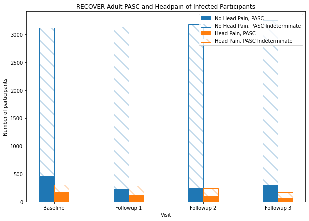

```python
# Create bar plots with data - stacked by PASC/PASC indeterminate, separated by visit
N = 4

ind = np.arange(N)
width = 0.2

br2 = [x + width for x in ind]

fig = plt.subplots(figsize = (10,7))
p1 = plt.bar(ind, nopain_pasc, width, color = "tab:blue", edgecolor = "tab:blue", label = "No Head Pain, PASC")
p2 = plt.bar(ind, nopain_nopasc, width, bottom=nopain_pasc, color="w", hatch = "\\", edgecolor = "tab:blue", label = "No Head Pain, PASC Indeterminate")
p3 = plt.bar(br2, pain_pasc, width, color="tab:orange", edgecolor = "tab:orange", label = "Head Pain, PASC")
p4 = plt.bar(br2, pain_nopasc, width, bottom=pain_pasc, color="w", hatch="\\", edgecolor = "tab:orange", label = "Head Pain, PASC Indeterminate")

plt.xticks(ind+width*0.5, ('Baseline', 'Followup 1', 'Followup 2', 'Followup 3'))
plt.legend()

plt.ylabel("Number of participants")
plt.xlabel("Visit")
plt.title("RECOVER Adult PASC and Headpain of Infected Participants")
```